# Projects

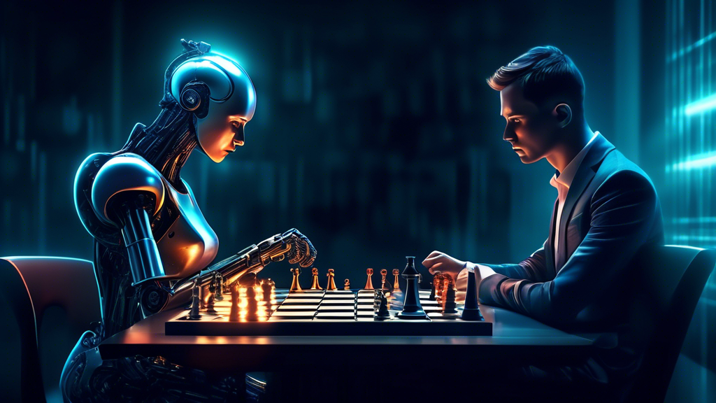

### [ChessMate: A LLM based Chatbot for Chess](https://briansoonwookwon.github.io/docs/dsan_6725/report.html)

ChessMate is a Streamlit web app that lets users play chess against an LLM and Stockfish, while offering a text interface for move suggestions via RAG over grandmaster games, a fine-tuned model, chess.com articles, and live web search.

[figure not shown]

### [WatchDogAI](https://briansoonwookwon.github.io/docs/dsan_6500/report.html)

This project aims to detect AI-generated images in election officials’ social media posts about voter information as a first step toward studying potential mistrust in the voter information space.

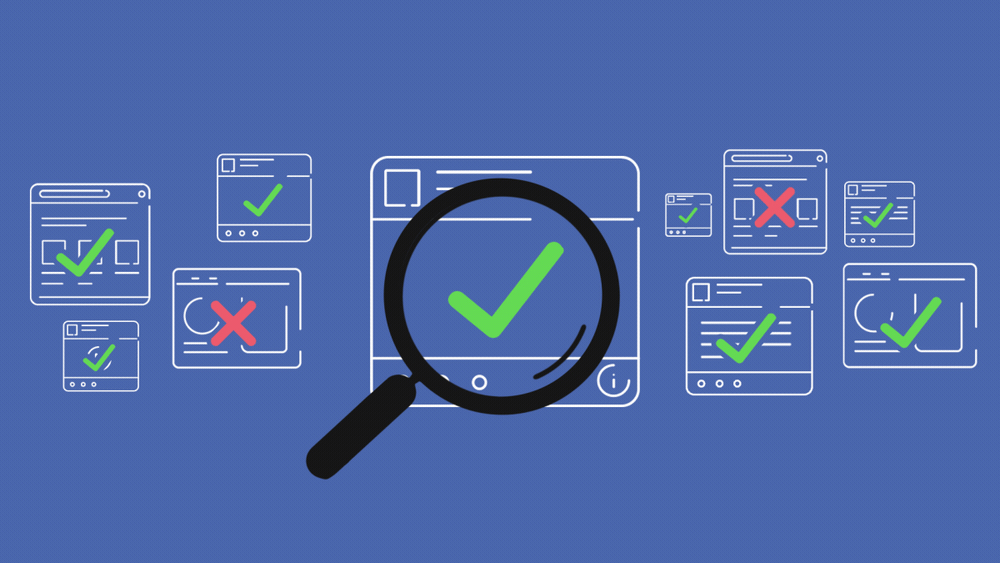

### [Information Retrieval: CrisisFACTS](https://github.com/briansoonwookwon/CrisisFACTS)

A Python package on Information Retrieval : CrisisFACTS

[figure not shown]

### [Patterns in U.S. Political Discussions](https://briansoonwookwon.github.io/docs/dsan_6000/)

Big Data Analysis Project on Reddit understanding trends and changes of U.S. political discussions in subreddits.

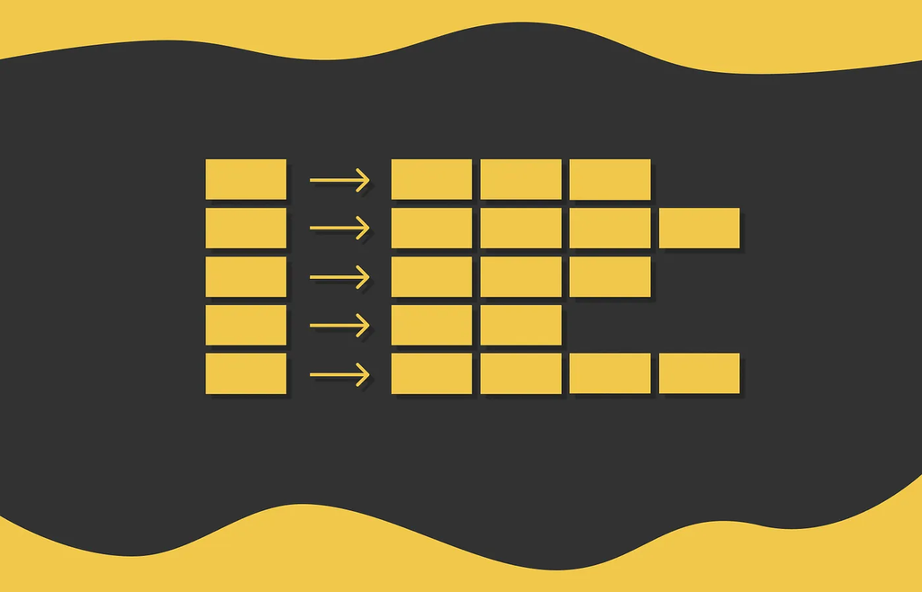

### [LSH with improvements from scratch for Similarity Search](https://github.com/briansoonwookwon/LSH)

A Python package of LSH with two additional improvements to identify near duplicate files.

[figure not shown]

### [Feature Engineered Regression Analysis on Airbnb Short Term Rental Market](https://briansoonwookwon.github.io/docs/dsan_5300/)

Data Analysis on Airbnb data predicting the rental price and finding important features.

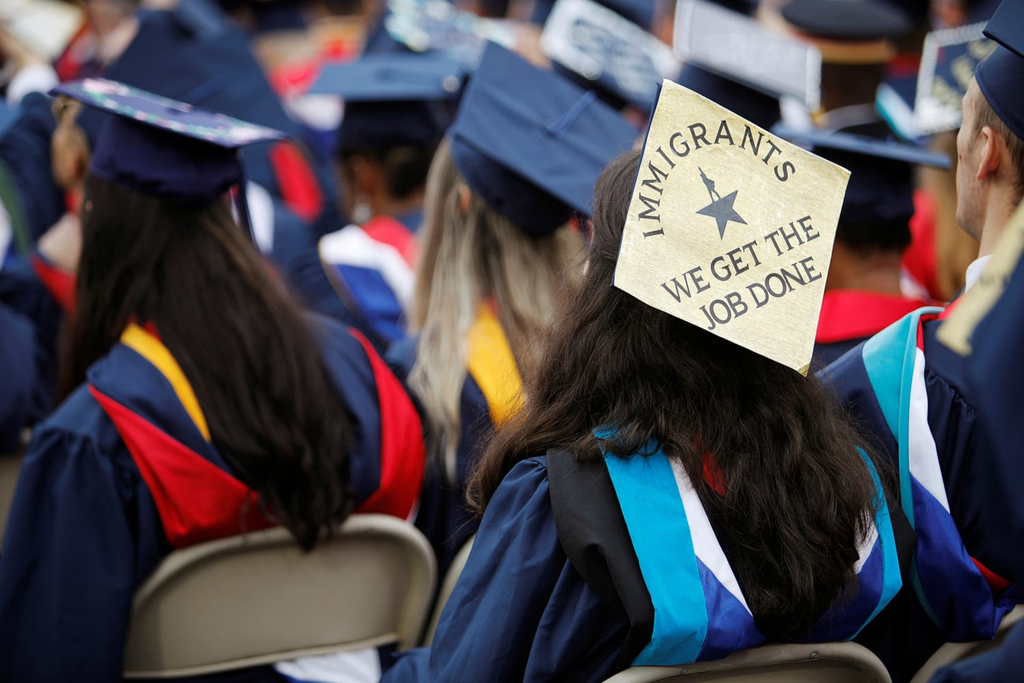

### [Why immigrants are successful?](https://briansoonwookwon.github.io/docs/dsan_5000/)

Comparison on the success between immigrants and native-borns in the U.S. using various machine learning methods.

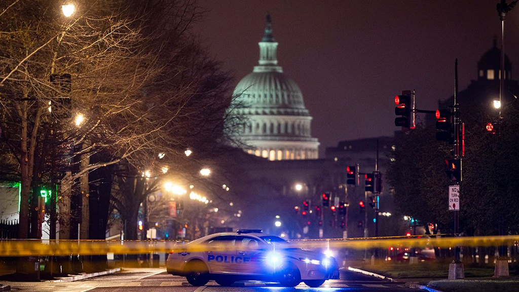

### [DC Crime Trend Analysis from 2018 - 2022](https://briansoonwookwon.github.io/docs/dsan_5200/)

Data Visualization report on Washington D.C. Crime Date from 2018-2022.

[figure not shown]

### [Behind the Beats: A Feature Analysis of Songs by Spotify’s Fab Five](https://briansoonwookwon.github.io/docs/dsan_5100/)

Statistical analysis on seven audio features of songs from five most streamed artists of 2022 in spotify.